# Juego de Squash

Magdiel Ablan

11 de marzo de 2016

El juego de squash lo juegan dos personas: jugador 1 y jugador 2. El juego consiste en una secuencia de puntos.Si el jugador i sirve y gana el punto su puntuación se incrementa en 1 y sigue sirviendo.Si el jugador i sirve y pierde el punto el servicio se transfiere al otro jugador y la puntuación permanece igual.

El ganador es la primera persona que alcanza una puntuación de 9, a menos que la puntuación sea de 8 para ambos primero. Si este fuera el caso el juego continua hasta que un jugador se encuentra dos puntos por arriba del otro en cuyo caso, él es el ganador.

El objetivo de esta tarea es simular un juego de squash y estimar la probabilidad de que gane el jugador 1. Definimos: $a=\mathbb{P}(jugador\: 1\: gana\: punto\:/\: jugador\: 1\: sirve)$ $b=\mathbb{P}(jugador\: 1\: gana\: punto\: /\: jugador\: 2\: sirve)$ $x= puntuacion\: jugador\: 1$ $y= puntuacion\: jugador\: 2$ $z=\left\{\begin{matrix} 1 & si\: el\: jugador\: 1\: esta\: sirviendo \\ 2 & si\: el\: jugador\: 2\: esta\: sirviendo \end{matrix}\right.$

### Estado del juego

Escriba una función `status` que tome como entrada x y y retorne uno de los siguientes mensajes.

`sin terminar`: si el juego aun no ha finalizado

`ganó 1`: si el jugador 1 ganó

`ganó 2`: si el jugador 2 ganó

`imposible`: si la puntuación no es válida

Puede asumir que las entrada x y y son números enteros.

```r
status<-function(x,y) {
  diferencia = abs(x-y)
  mayor=max(x,y)
  if ((x < 0) | (y<0)) {
    status="imposible"
    return(status)
  }

  if ((mayor > 9) & (diferencia >= 3)) {
    status="imposible"
    return(status)
  }



  if (mayor <= 8) {
    status="sin terminar"
    return(status)
  }
  if (mayor>=9) {
    if (diferencia<2) {
      status="sin terminar"
      return(status)
    }
    else if (mayor==x) {
          status="Gana 1"
          return(status)
          } else if (mayor==y) {
                  status="Gana 2"
                  return(status)
                  } else {
                    status="imposible"
                    return(status)
                  }
        }

  }
```

Una vez que haya escrito la función, cargue la función `status.test` dada a continuación:

```r
status.test <- function(s.ftn) {
x.vec <- (-1):11
y.vec <- (-1):11
plot(x.vec, y.vec, type = "n", xlab = "x", ylab = "y")
for (x in x.vec) {
  for (y in y.vec) {
    s <- s.ftn(x, y)
  if (s == "imposible") text(x, y, "X", col = "red")
  else if (s == "sin terminar") text(x, y, "?", col = "blue")
  else if (s == "Gana 1") text(x, y, "1", col = "green")
  else if (s == "Gana 2") text(x, y, "2", col = "green")
}
}
return(invisible(NULL))
}
```

La ejecución:

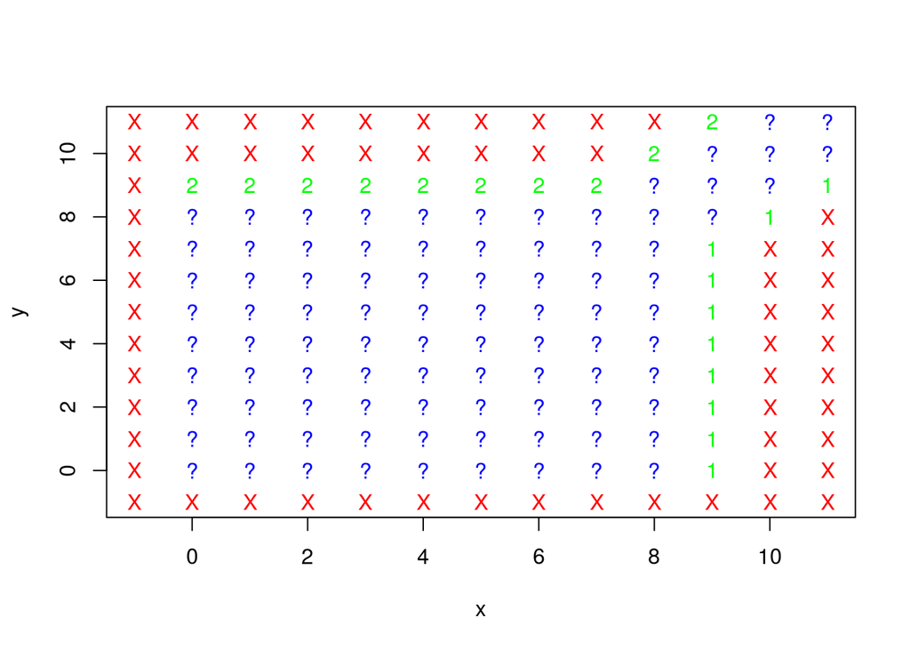

```r
status.test(status)
```

### Simulación de un juego

El vector `estado=(x,y,z)` describe el estado actual de un juego. Escriba una función `play_point` que toma como entradas: `estado`, `a` y `b`, simula la jugada de un punto y luego devuelve el valor actualizado de `estado` representando el nuevo estado del juego.

```r
play_point<-function(estado,a,b) {
  x=estado[1]
  y=estado[2]
  z=estado[3]

  #El jugador 1 tiene el servicio:
  if (z==1) {
    u<-runif(1)
    #si gana o pierde
    if (u<=a) x=x+1 else z=2
  } else {
    #El jugador 2 tiene el servicio
    u<-runif(1)
    #si pierde o gana
    if (u<=b) z=1 else y=y+1
  }
  estado=c(x,y,z)
}
```

Ahora, codifique la funcion `play_game` exactamente como sigue:

```r
play_game <- function(a, b) {
state <- c(0, 0, 1)
while (status(state[1], state[2]) == "sin terminar") {
# show(state)
state <- play_point(state, a, b)
}
if (status(state[1], state[2]) == "Gana 1") {
return(TRUE)
} else {
return(FALSE)
}
}
```

Si su función `status` y `play_point` funcionan adecuadamente, la función `play_game` simula un juego de squash y devuelve TRUE si el jugador 1 gana y FALSE en caso contrario.

Primero, hacemos una función que calcula la probabilidad de que el jugador gane en n juegos dados a y b:

```r
prob_ganar<-function(a,b,n){
  sum(as.integer(replicate(n,play_game(a,b))))/n
}
```

y luego, la llamamos repetidas veces para hacer el gráfico:

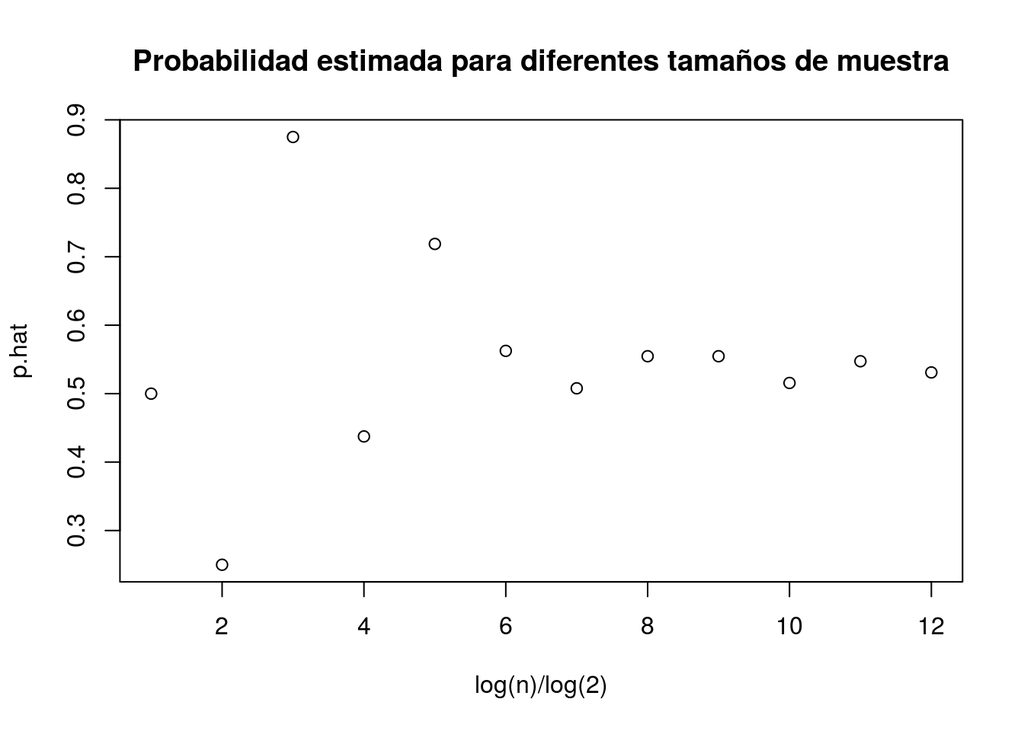

```r
set.seed(1)
k=1:12
n=2^k
ejex=log(n)/log(2)
ejey=numeric(12)

for (i in 1:12) {
  ejey[i]=prob_ganar(0.55,0.45,n[i])
}

plot(ejex,ejey,type="p",main="Probabilidad estimada para diferentes tamaños de muestra",xlab="log(n)/log(2)",ylab="p.hat")
```

Note que el codigo debe especificar la semilla para el generador de numeros aleatorios de manera de poder reproducir los resultados exactamente de ser necesario.

### Probabilidad de ganar

Sea $X_{1},...X_{n}$ una muestra IID de variables Bernoulli(p). Usamos $\hat{p}=\bar{X}$ para estimar el valor de p. Muestre que: $Var\: \hat{p} = p(1-p)/n$. *Respuesta:*

$Var\: \bar{X} = Var\sum \frac{X_i}{n} \\ = \frac{1}{n^2} \sum Var(X_i) \\ = \frac{1}{n^2} \sum p(1-p) \\ = \frac{1}{n^2} \times n\times p(1-p) \\ = \frac{p(1-p)}{n}$

La desviación estándar es la raíz cuadrada de la varianza. ¿Qué valor de n garantizará que la desviación estándar de $\hat{p} \leqslant 0.01$ para cualquier valor de p?

Usando el valor de $n$ calculado anteriormente reproduzca la siguiente tabla que estima $p(a,b)$ para diferentes valores de $a$ y $b$.

```r
#Probabilidad de ganar:
a=seq(0.1,0.9,0.1)
b=seq(0.1,0.9,0.1)
tabla=matrix(0,9,9)
n=2500
prob_ganar.V=Vectorize(prob_ganar)
set.seed(1)
tabla=outer(a,b,"prob_ganar.V",n)
colnames(tabla)= paste("b=",b)
rownames(tabla)=paste("a=",a)
print(tabla,digits=2)
```

```
##        b= 0.1 b= 0.2 b= 0.3 b= 0.4 b= 0.5 b= 0.6 b= 0.7 b= 0.8 b= 0.9
## a= 0.1 0.0000 0.0000 0.0000 0.0000  0.000 0.0016 0.0048  0.057   0.49
## a= 0.2 0.0000 0.0000 0.0004 0.0024  0.011 0.0432 0.1808  0.506   0.96
## a= 0.3 0.0008 0.0016 0.0108 0.0288  0.088 0.2420 0.5252  0.861   0.99
## a= 0.4 0.0044 0.0192 0.0492 0.1264  0.288 0.5184 0.7980  0.961   1.00
## a= 0.5 0.0188 0.0700 0.1584 0.3116  0.535 0.7572 0.9268  0.993   1.00
## a= 0.6 0.0568 0.1728 0.3476 0.5496  0.768 0.9164 0.9768  0.998   1.00
## a= 0.7 0.1560 0.3736 0.5624 0.7588  0.889 0.9732 0.9956  1.000   1.00
## a= 0.8 0.3644 0.5832 0.7756 0.9028  0.965 0.9932 0.9996  1.000   1.00
## a= 0.9 0.6456 0.8280 0.9272 0.9764  0.994 1.0000 0.9996  1.000   1.00
```

### Longitud del juego

Modifique la función `play_game` para que retorne el número de puntos jugados en el juego (en vez del estatus de ganador del jugador 1). Use la la función modificada para reproducir la siguiente tabla, que estima el número esperado de puntos jugados en un juego para diferentes valores de $a$ y $b$. Use el mismo valor de $n$ que anteriormente.

De manera similar a lo realizado anteriormente, definimos una funcion `play_game_cuenta` :

```r
play_game_cuenta<-function(a, b) {
  state <- c(0,0, 1)
  cuenta<-0
  while (status(state[1], state[2]) == "sin terminar") {
    # show(state)
    state <- play_point(state, a, b)
    cuenta<-cuenta+1
  }
    return(cuenta)
}
```

Y similar a `prob_ganar`, `cuenta_puntos`:

```r
cuenta_puntos<-function(a,b,n){
  sum(replicate(n,play_game_cuenta(a,b)))/n
}
```

Ahora si generamos la tabla:

```r
a=seq(0.1,0.9,0.1)
b=seq(0.1,0.9,0.1)
tabla=matrix(0,9,9)
n=2500
cuenta_puntos.V=Vectorize(cuenta_puntos)
set.seed(1)
tabla=outer(a,b,"cuenta_puntos.V",n)
colnames(tabla)= paste("b=",b)
rownames(tabla)=paste("a=",a)
print(tabla,digits=4)
```

```
##        b= 0.1 b= 0.2 b= 0.3 b= 0.4 b= 0.5 b= 0.6 b= 0.7 b= 0.8 b= 0.9
## a= 0.1  12.22  14.87  18.27  22.81  28.95  39.03  54.67  85.67 150.54
## a= 0.2  12.55  15.38  18.83  23.86  30.26  40.26  55.02  73.80  84.93
## a= 0.3  12.99  15.85  19.71  25.04  31.49  39.98  48.72  54.07  52.89
## a= 0.4  13.34  16.60  20.51  25.35  30.76  35.83  38.98  39.40  37.30
## a= 0.5  13.92  17.32  21.03  25.23  28.23  29.93  30.20  29.35  28.05
## a= 0.6  14.31  17.59  20.36  22.80  23.74  23.86  23.17  22.33  21.75
## a= 0.7  14.72  17.08  18.67  19.51  19.66  19.20  18.38  17.76  17.04
## a= 0.8  14.38  15.64  16.17  15.88  15.55  15.08  14.57  13.98  13.86
## a= 0.9  12.58  12.97  12.69  12.35  11.93  11.59  11.46  11.23  11.13
```

### A mencionar:

- El uso de la opción `cache=TRUE` para evitar repetir cálculos muy largos
- El uso de la función `Vectorize`
- Pendiente: Hacerlo usando cadenas de Markov
- Pendiente: Alineación de formulas en Latex